# DV_RProject1

Ronly Leung, Karen Lee

September 15, 2015

```r
require("jsonlite")
require("RCurl")
require(extrafont)
require(ggplot2)
```

## Data Frames

### Data Frame using SQL query “select * from titanic”

```r
source("../01 Data/DF_1.R", echo = TRUE)
```

```
##
## > require("jsonlite")
##
## > require("RCurl")
##
## > require(extrafont)
##
## > require(ggplot2)
##
## > df1 <- data.frame(fromJSON(getURL(URLencode("129.152.144.84:5001/rest/native/?query=\"select * from titanic\""),
## +     httpheader = c(DB = "jdbc:or ..." ... [TRUNCATED]
##
## > head(df1)
##   PASSENGERID SURVIVED PCLASS                        NAME    SEX AGE SIBSP
## 1         207        0      3  Backstrom, Mr. Karl Alfred   male  32     1
## 2         208        1      3 Albimona, Mr. Nassef Cassem   male  26     0
## 3         209        1      3     Carr, Miss. Helen Ellen female  16     0
## 4         210        1      1            Blank, Mr. Henry   male  40     0
## 5         211        0      3              Ali, Mr. Ahmed   male  24     0
## 6         212        1      2  Cameron, Miss. Clear Annie female  35     0
##   PARCH             TICKET             FARE CABIN EMBARKED
## 1     0            3101278 15.8500003814697  null        S
## 2     0               2699 18.7875003814697  null        C
## 3     0             367231             7.75  null        Q
## 4     0             112277               31   A31        C
## 5     0 SOTON/O.Q. 3101311 7.05000019073486  null        S
## 6     0       F.C.C. 13528               21  null        S
##
## > summary(df1)
##                                       PASSENGERID  SURVIVED    PCLASS
##  </pre></body></html>Xtext/csvUUTF-8(?N`vPJS:  1   0   :549   1   :216
##  1                                          :  1   1   :342   2   :184
##  10                                         :  1   null:  2   3   :491
##  100                                        :  1              null:  2
##  101                                        :  1
##  102                                        :  1
##  (Other)                                    :887
##                                     NAME         SEX           AGE
##  null                                 :  2   female:314   null   :179
##  Abbing, Mr. Anthony                  :  1   male  :577   24     : 30
##  Abbott, Mr. Rossmore Edward          :  1   null  :  2   22     : 27
##  Abbott, Mrs. Stanton (Rosa Hunt)     :  1                18     : 26
##  Abelson, Mr. Samuel                  :  1                19     : 25
##  Abelson, Mrs. Samuel (Hannah Wizosky):  1                28     : 25
##  (Other)                              :886                (Other):581
##      SIBSP         PARCH          TICKET                  FARE
##  0      :608   0      :678   1601    :  7   8.05000019073486: 43
##  1      :209   1      :118   347082  :  7   13              : 42
##  2      : 28   2      : 80   CA. 2343:  7   7.89580011367798: 38
##  4      : 18   3      :  5   3101295 :  6   7.75            : 34
##  3      : 16   5      :  5   347088  :  6   26              : 31
##  8      :  7   4      :  4   CA 2144 :  6   10.5            : 24
##  (Other):  7   (Other):  3   (Other) :854   (Other)         :681
##          CABIN     EMBARKED
##  null       :689   C   :168
##  B96 B98    :  4   null:  4
##  C23 C25 C27:  4   Q   : 77
##  G6         :  4   S   :644
##  C22 C26    :  3
##  D          :  3
##  (Other)    :186
```

### Data Frame using SQL query “select * from titanic where sex is not null”

```r
source("../01 Data/DF_2.R", echo = TRUE)
```

```
##
## > require("jsonlite")
##
## > require("RCurl")
##
## > require(extrafont)
##
## > require(ggplot2)
##
## > df2 <- data.frame(fromJSON(getURL(URLencode("129.152.144.84:5001/rest/native/?query=\"select * from titanic where sex is not null\""),
## +     httphe .... [TRUNCATED]
##
## > head(df2)
##   PASSENGERID SURVIVED PCLASS                        NAME    SEX AGE SIBSP
## 1         207        0      3  Backstrom, Mr. Karl Alfred   male  32     1
## 2         208        1      3 Albimona, Mr. Nassef Cassem   male  26     0
## 3         209        1      3     Carr, Miss. Helen Ellen female  16     0
## 4         210        1      1            Blank, Mr. Henry   male  40     0
## 5         211        0      3              Ali, Mr. Ahmed   male  24     0
## 6         212        1      2  Cameron, Miss. Clear Annie female  35     0
##   PARCH             TICKET    FARE CABIN EMBARKED
## 1     0            3101278 15.8500  null        S
## 2     0               2699 18.7875  null        C
## 3     0             367231  7.7500  null        Q
## 4     0             112277 31.0000   A31        C
## 5     0 SOTON/O.Q. 3101311  7.0500  null        S
## 6     0       F.C.C. 13528 21.0000  null        S
##
## > summary(df2)
##   PASSENGERID       SURVIVED          PCLASS
##  Min.   :  1.0   Min.   :0.0000   Min.   :1.000
##  1st Qu.:223.5   1st Qu.:0.0000   1st Qu.:2.000
##  Median :446.0   Median :0.0000   Median :3.000
##  Mean   :446.0   Mean   :0.3838   Mean   :2.309
##  3rd Qu.:668.5   3rd Qu.:1.0000   3rd Qu.:3.000
##  Max.   :891.0   Max.   :1.0000   Max.   :3.000
##
##                                     NAME         SEX           AGE
##  Abbing, Mr. Anthony                  :  1   female:314   null   :177
##  Abbott, Mr. Rossmore Edward          :  1   male  :577   24     : 30
##  Abbott, Mrs. Stanton (Rosa Hunt)     :  1                22     : 27
##  Abelson, Mr. Samuel                  :  1                18     : 26
##  Abelson, Mrs. Samuel (Hannah Wizosky):  1                19     : 25
##  Adahl, Mr. Mauritz Nils Martin       :  1                28     : 25
##  (Other)                              :885                (Other):581
##      SIBSP           PARCH             TICKET         FARE
##  Min.   :0.000   Min.   :0.0000   1601    :  7   Min.   :  0.00
##  1st Qu.:0.000   1st Qu.:0.0000   347082  :  7   1st Qu.:  7.91
##  Median :0.000   Median :0.0000   CA. 2343:  7   Median : 14.45
##  Mean   :0.523   Mean   :0.3816   3101295 :  6   Mean   : 32.20
##  3rd Qu.:1.000   3rd Qu.:0.0000   347088  :  6   3rd Qu.: 31.00
##  Max.   :8.000   Max.   :6.0000   CA 2144 :  6   Max.   :512.33
##                                   (Other) :852
##          CABIN     EMBARKED
##  null       :687   C   :168
##  B96 B98    :  4   null:  2
##  C23 C25 C27:  4   Q   : 77
##  G6         :  4   S   :644
##  C22 C26    :  3
##  D          :  3
##  (Other)    :186
```

### Data Frame using SQL query “select * from titanic where age <= 10”

```r
source("../01 Data/DF_3.R", echo = TRUE)
```

```
##
## > require("jsonlite")
##
## > require("RCurl")
##
## > require(extrafont)
##
## > require(ggplot2)
##
## > df3 <- data.frame(fromJSON(getURL(URLencode("129.152.144.84:5001/rest/native/?query=\"select * from titanic where age <= 10\""),
## +     httpheader = .... [TRUNCATED]
##
## > head(df3)
##   PASSENGERID SURVIVED PCLASS                              NAME    SEX
## 1         234        1      3    Asplund, Miss. Lillian Gertrud female
## 2         238        1      2    Collyer, Miss. Marjorie Lottie female
## 3         262        1      3 Asplund, Master. Edvin Rojj Felix   male
## 4         279        0      3                Rice, Master. Eric   male
## 5         298        0      1      Allison, Miss. Helen Loraine female
## 6         306        1      1    Allison, Master. Hudson Trevor   male
##    AGE SIBSP PARCH     TICKET     FARE   CABIN EMBARKED
## 1 5.00     4     2     347077  31.3875    null        S
## 2 8.00     0     2 C.A. 31921  26.2500    null        S
## 3 3.00     4     2     347077  31.3875    null        S
## 4 7.00     4     1     382652  29.1250    null        Q
## 5 2.00     1     2     113781 151.5500 C22 C26        S
## 6 0.92     1     2     113781 151.5500 C22 C26        S
##
## > summary(df3)
##   PASSENGERID       SURVIVED          PCLASS
##  Min.   :  8.0   Min.   :0.0000   Min.   :1.000
##  1st Qu.:183.8   1st Qu.:0.0000   1st Qu.:2.000
##  Median :414.0   Median :1.0000   Median :3.000
##  Mean   :430.8   Mean   :0.5938   Mean   :2.641
##  3rd Qu.:699.2   3rd Qu.:1.0000   3rd Qu.:3.000
##  Max.   :870.0   Max.   :1.0000   Max.   :3.000
##
##                                       NAME        SEX          AGE
##  Allison, Master. Hudson Trevor         : 1   female:31   Min.   : 0.420
##  Allison, Miss. Helen Loraine           : 1   male  :33   1st Qu.: 2.000
##  Andersson, Master. Sigvard Harald Elias: 1               Median : 4.000
##  Andersson, Miss. Ebba Iris Alfrida     : 1               Mean   : 4.268
##  Andersson, Miss. Ellis Anna Maria      : 1               3rd Qu.: 7.000
##  Andersson, Miss. Ingeborg Constanzia   : 1               Max.   :10.000
##  (Other)                                :58
##      SIBSP           PARCH           TICKET        FARE
##  Min.   :0.000   Min.   :0.000   347082 : 4   Min.   :  8.517
##  1st Qu.:0.750   1st Qu.:1.000   347088 : 4   1st Qu.: 19.131
##  Median :1.000   Median :1.000   382652 : 4   Median : 27.000
##  Mean   :1.844   Mean   :1.422   2666   : 3   Mean   : 30.434
##  3rd Qu.:3.250   3rd Qu.:2.000   3101295: 3   3rd Qu.: 31.387
##  Max.   :5.000   Max.   :2.000   347077 : 3   Max.   :151.550
##                                  (Other):43
##      CABIN    EMBARKED
##  A34    : 1   C: 9
##  C22 C26: 2   Q: 4
##  E121   : 1   S:51
##  F2     : 2
##  F4     : 2
##  G6     : 2
##  null   :54
```

### Data Frame using SQL query “select * from titanic where age > 50”

```r
source("../01 Data/DF_4.R", echo = TRUE)
```

```
##
## > require("jsonlite")
##
## > require("RCurl")
##
## > require(extrafont)
##
## > require(ggplot2)
##
## > df4 <- data.frame(fromJSON(getURL(URLencode("129.152.144.84:5001/rest/native/?query=\"select * from titanic where age > 50\""),
## +     httpheader =  .... [TRUNCATED]
##
## > head(df4)
##   PASSENGERID SURVIVED PCLASS
## 1         223        0      3
## 2         233        0      2
## 3         250        0      2
## 4         253        0      1
## 5         263        0      1
## 6         269        1      1
##                                            NAME    SEX AGE SIBSP PARCH
## 1                       Green, Mr. George Henry   male  51     0     0
## 2                     Sjostedt, Mr. Ernst Adolf   male  59     0     0
## 3                 Carter, Rev. Ernest Courtenay   male  54     1     0
## 4                     Stead, Mr. William Thomas   male  62     0     0
## 5                             Taussig, Mr. Emil   male  52     1     1
## 6 Graham, Mrs. William Thompson (Edith Junkins) female  58     0     1
##     TICKET     FARE CABIN EMBARKED
## 1    21440   8.0500  null        S
## 2   237442  13.5000  null        S
## 3   244252  26.0000  null        S
## 4   113514  26.5500   C87        S
## 5   110413  79.6500   E67        S
## 6 PC 17582 153.4625  C125        S
##
## > summary(df4)
##   PASSENGERID       SURVIVED          PCLASS
##  Min.   :  7.0   Min.   :0.0000   Min.   :1.000
##  1st Qu.:230.5   1st Qu.:0.0000   1st Qu.:1.000
##  Median :486.0   Median :0.0000   Median :1.000
```

[output cut: 13 more lines]

```
##  Min.   :51.00   Min.   :0.00   Min.   :0.0000   13502  : 2
##  1st Qu.:54.00   1st Qu.:0.00   1st Qu.:0.0000   36947  : 2
##  Median :58.00   Median :0.00   Median :0.0000   110413 : 1
##  Mean   :58.72   Mean   :0.25   Mean   :0.2969   110813 : 1
##  3rd Qu.:62.00   3rd Qu.:0.00   3rd Qu.:0.0000   111240 : 1
##  Max.   :80.00   Max.   :2.00   Max.   :4.0000   113055 : 1
##                                                  (Other):56
##       FARE             CABIN    EMBARKED
##  Min.   :  6.237   null   :31   C   :15
##  1st Qu.: 12.881   D20    : 2   null: 1
##  Median : 28.125   A23    : 1   Q   : 3
##  Mean   : 43.605   A26    : 1   S   :45
##  3rd Qu.: 64.234   A5     : 1
##  Max.   :263.000   A7     : 1
##                    (Other):27
```

## Visualization 1

```r
source("../02 Visualizations/DV_1.R", echo = TRUE)
```

```
##
## > ggplot() + coord_cartesian() + scale_x_continuous() +
## +     scale_y_continuous() + labs(title = "Titanic") + labs(x = "Age",
## +     y = paste("Fare ..." ... [TRUNCATED]
```

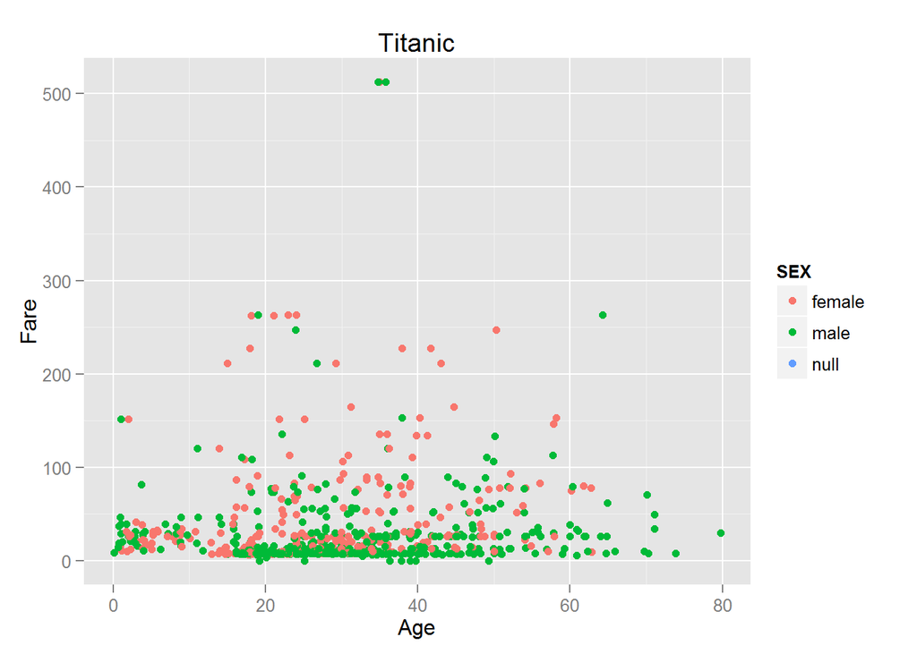

1. SQL Query: select * from titanic
2. Use Cartesian coordinates
3. X and Y scales are both continuous
4. Set title to “Titanic”
5. Set x-axis to “Age” and y-axis to “Fare”
6. Create a layer
- X is Age, Y is Fare, Color is Sex
- set stat to “identity”
- set geom to “point”
- use jitter (width=0.3, height=0)

This visualization shows each passenger’s fare based on his/her age and sex (sex can be null). The x-axis is the age of the passengers, y-axis is the fare paid by the passenger, and the legend is sex (sex can be null). This graph did not require any facets.

## Visualization 2

```r
source("../02 Visualizations/DV_2.R", echo = TRUE)
```

```
##
## > ggplot() + coord_cartesian() + scale_x_continuous() +
## +     scale_y_continuous() + labs(title = "Titanic") + labs(x = "Age",
## +     y = paste("Fare ..." ... [TRUNCATED]
```

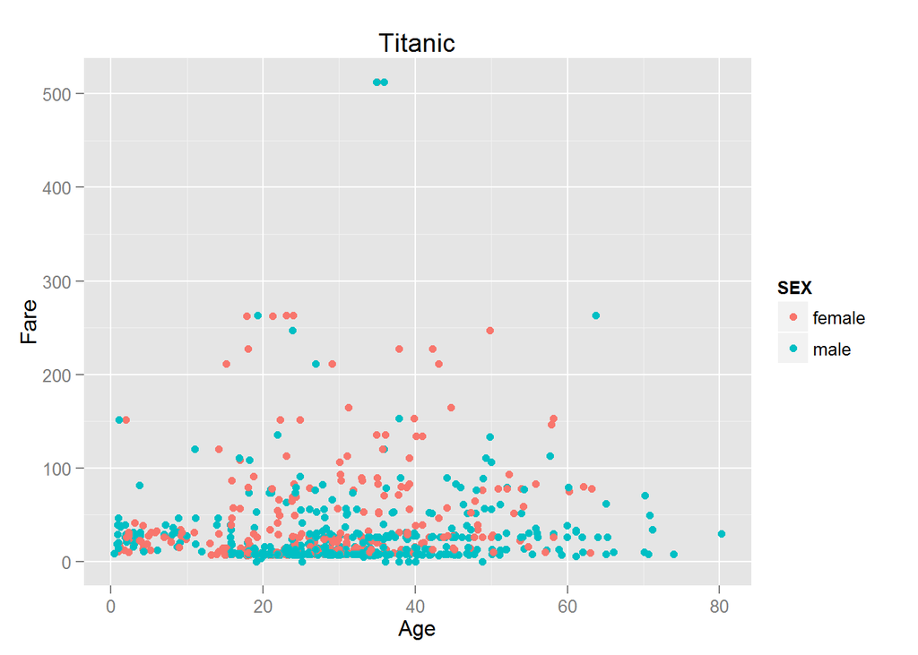

- SQL Query: select * from titanic where sex is not null
- This visualization shows each passenger’s fare based on his/her age and sex (sex can’t be null).
- The x-axis is the age of the passengers, y-axis is the fare paid by the passenger, and the legend is sex (excluding sex as null).
- This graph did not require any facets.

## Visualization 3

```r
source("../02 Visualizations/DV_3.R", echo = TRUE)
```

```
##
## > ggplot() + coord_cartesian() + scale_x_discrete() +
## +     scale_y_continuous() + labs(title = "Titanic") + labs(x = "SURVIVED",
## +     y = paste("F ..." ... [TRUNCATED]
```

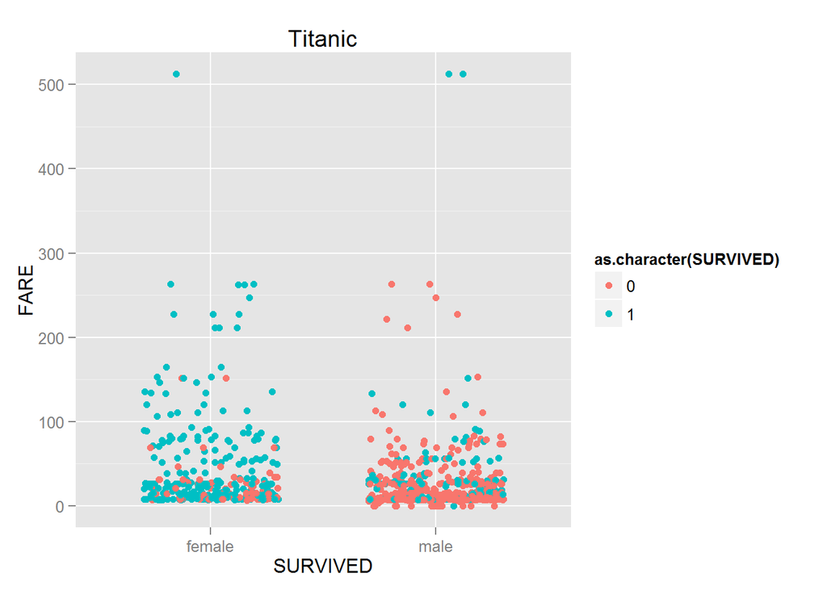

- SQL Query: select * from titanic where sex is not null
- This visualization shows whether each passenger survived or not vs their fare, with the x-axis separated by sex.
- The x-axis is divided by sex (male and female), y-axis is the fare paid by the passenger, and the legend is the survival status.
- This graph did not require any facets.

## Visualization 4

```r
source("../02 Visualizations/DV_4.R", echo = TRUE)
```

```
##
## > ggplot() + coord_cartesian() + scale_x_discrete() +
## +     scale_y_continuous() + facet_grid(PCLASS ~ SURVIVED, labeller = label_both) +
## +     labs .... [TRUNCATED]
```

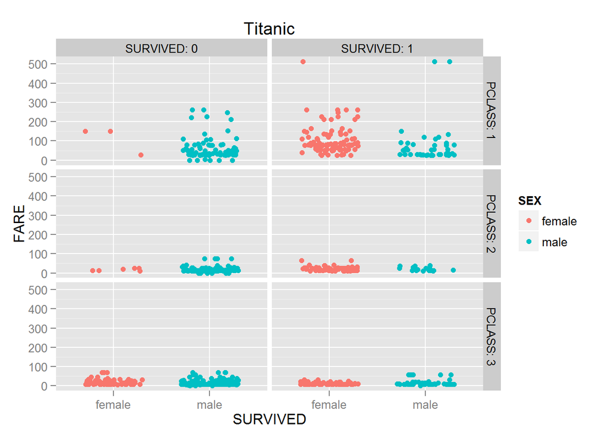

- SQL Query: select * from titanic where sex is not null
- This visualization categorizes passengers by class and survival status, resulting in 6 different graphs. Each graph plots fare to sex.
- The x-axis is divided by sex (male and female), y-axis is the fare paid by the passenger, and the legend is sex (excluding sex as null).
- This graph did use a facet which split the graphs into SURVIVED and PCLASS.

## Visualization 5

```r
source("../02 Visualizations/DV_5.R", echo = TRUE)
```

```
##
## > ggplot() + coord_cartesian() + scale_x_discrete() +
## +     scale_y_continuous() + facet_grid(PCLASS ~ SURVIVED, labeller = label_both) +
## +     labs .... [TRUNCATED]
```

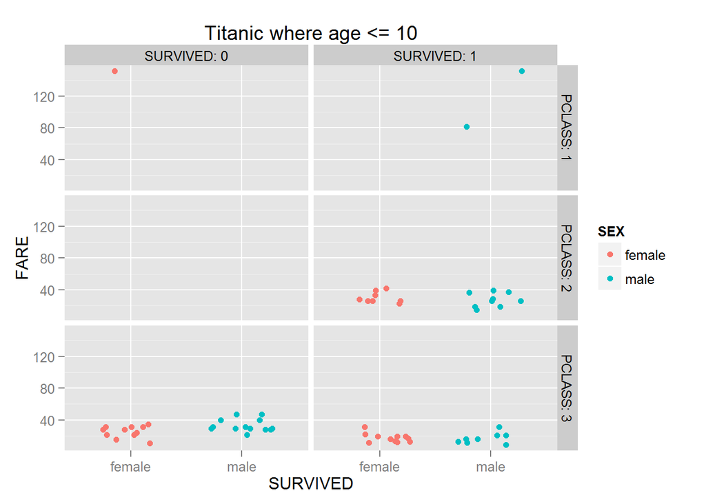

- SQL Query: select * from titanic where age <= 10
- This visualization also categorizes passengers, 10 years and younger, by class and survival status, resulting in 6 different graphs. Each graph plots fare to sex.
- The x-axis is divided by sex (male and female), y-axis is the fare paid by the passenger, and the legend is sex (excluding sex as null).
- This graph did use a facet which split the graphs into SURVIVED and PCLASS.

## Our Own Creation!

```r
source("../02 Visualizations/DV_6.R", echo = TRUE)
```

```
##
## > ggplot() + coord_cartesian() + scale_x_discrete() +
## +     scale_y_continuous() + labs(title = "Titanic where age > 50") +
## +     labs(x = "SURVIVED ..." ... [TRUNCATED]
```

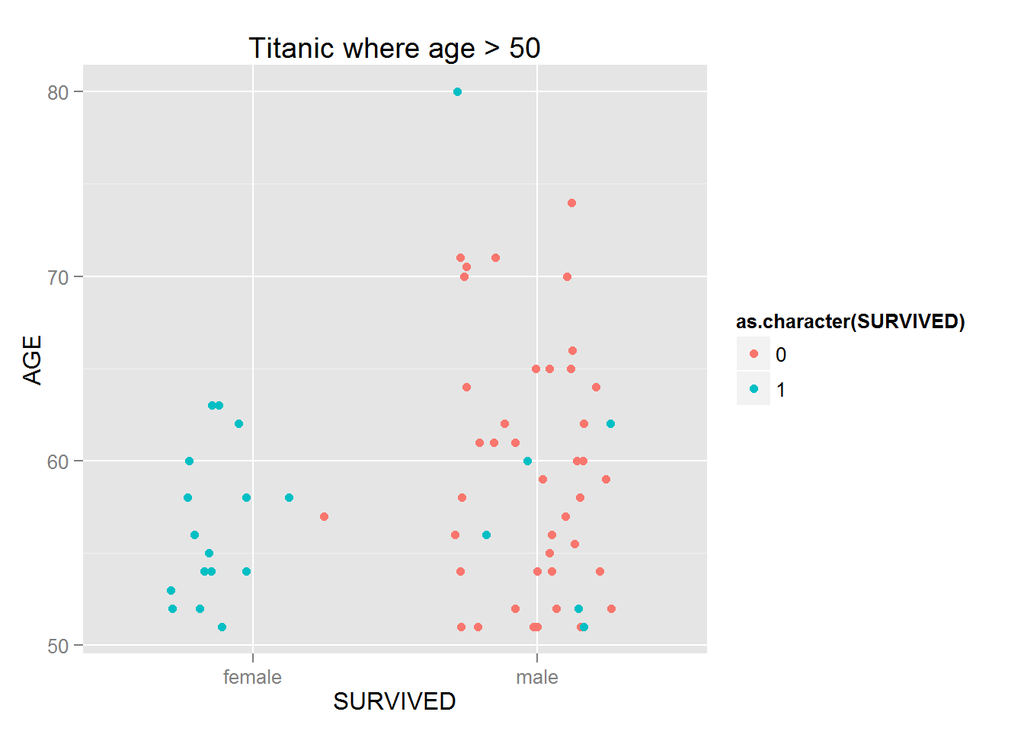

- SQL Query: select * from titanic where age > 50
- This visualization compares the age and survival status of passengers over the age of 50. The graph separates the passengers by sex.
- The x-axis is divided by sex (male and female), y-axis is the age of the passenger, and the legend is the survival status.
- This graph did not require any facets.